# Retail and Geodemographics: A Spatial Data Science Approach

Patrick Ballantyne

2022-09-23

# 1 Libraries

Libraries are an essential part of the R workflow, giving you all the necessary tools to complete the analysis. Different people use different libraries for certain aspects of analysis, but these are my favourites:

```r
library(tidyverse)
library(sf)
library(tidycensus)
library(tmap)
```

## 1.1 Store data - SafeGraph places

```r
places <- st_read("Data/places.gpkg", quiet = TRUE)
```

Look at the attributes:

```r
glimpse(places)
```

```
## Rows: 74,345
## Columns: 6
## $ location_name <chr> "Bookkeeping by Andrea", "Pereira and Company CPA", "Bra…
## $ placekey      <chr> "223-222@8g6-ygm-vs5", "22f-228@8g6-yqc-3nq", "22h-223@8…
## $ brands        <chr> "Independent", "Independent", "Independent", "Independen…
## $ top_category  <chr> "Accounting, Tax Preparation, Bookkeeping, and Payroll S…
## $ sub_category  <chr> "Other Accounting Services", "Other Accounting Services"…
## $ geom          <POINT [m]> POINT (1447863 -1071445), POINT (1429340 -1094894)…
```

Let’s take a look at the distribution of grocery stores:

```r
grocery <- places %>%
  filter(top_category == "Grocery Stores")
```

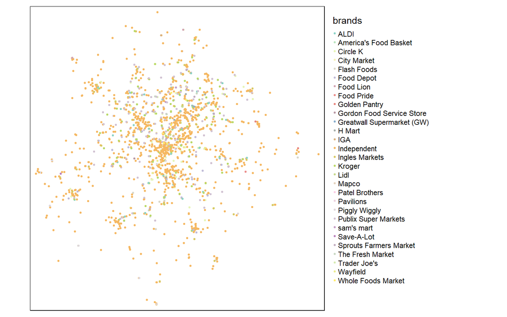

```r
tm_shape(grocery) +
  tm_dots(col = "brands", size = 0.05) +
  tm_layout(legend.outside = TRUE)
```

## 1.2 Geodemographic classification

```r
geodemo <- st_read("Data/geodemographic.gpkg", quiet = TRUE)
```

Look at the attributes:

```r
glimpse(geodemo)
```

```
## Rows: 1,021
## Columns: 3
## $ GEOID      <chr> "01029959500", "01029959800", "01111000200", "01111000400",…
## $ TractGroup <chr> "C: Middle Income, Single Family Homes", "C: Middle Income,…
## $ geom       <MULTIPOLYGON [m]> MULTIPOLYGON (((1349586 -11..., MULTIPOLYGON (…
```

The ‘TractGroup’ column is the one we are interested in; every census tract in the US is assigned to one of 10 groups, based on the geodemographic characteristics of the area in question.

```r
tm_shape(geodemo) +
  tm_fill(col = "TractGroup", alpha = 0.5) +
  tm_borders(col = "black", lwd = 0.25) +
  tm_layout(legend.outside = TRUE)
```

```
## Some legend labels were too wide. These labels have been resized to 0.63, 0.62. Increase legend.width (argument of tm_layout) to make the legend wider and therefore the labels larger.
```

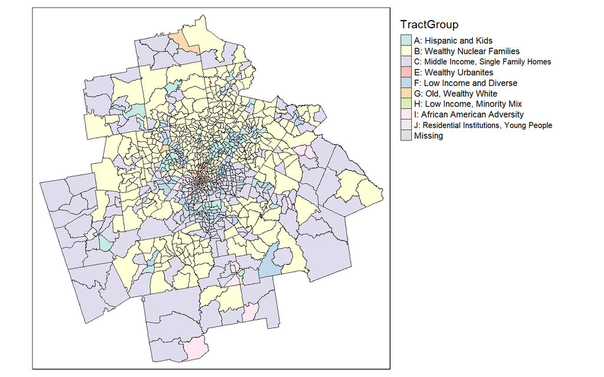

## 1.3 Population - US Census Bureau (via tidycensus)

We are going to be using a fantastic package called [‘tidycensus’](https://walker-data.com/tidycensus/) which is used to directly query data from the US Census Bureau API.

```r
## Remember to get an API key for the US Census Bureau
census_api_key("e0f3cdfa0e1e13ab3a4d9dc32c67984d0be5523b")
```

```
## To install your API key for use in future sessions, run this function with `install = TRUE`.
```

```r
pop <- get_decennial(geography = "Tract", variables = "P001001",
                     state = "GA", year = 2010)
```

Look at the attributes:

```r
glimpse(pop)
```

```
## Rows: 1,969
## Columns: 4
## $ GEOID    <chr> "13021012800", "13021013102", "13021012600", "13021012700", "…
## $ NAME     <chr> "Census Tract 128, Bibb County, Georgia", "Census Tract 131.0…
## $ variable <chr> "P001001", "P001001", "P001001", "P001001", "P001001", "P0010…
## $ value    <dbl> 3260, 4340, 4171, 2184, 1837, 6119, 6034, 2952, 4420, 4229, 4…
```

Here, the ‘value’ column is the one we are interested in; total population in each census tract. Let’s merge this onto the geodemographic classification:

```r
gd_pop <- merge(geodemo, pop, by = "GEOID")
```

```r
glimpse(gd_pop)
```

```
## Rows: 1,016
## Columns: 6
## $ GEOID      <chr> "13013180103", "13013180104", "13013180105", "13013180106",…
## $ TractGroup <chr> "C: Middle Income, Single Family Homes", "C: Middle Income,…
## $ NAME       <chr> "Census Tract 1801.03, Barrow County, Georgia", "Census Tra…
## $ variable   <chr> "P001001", "P001001", "P001001", "P001001", "P001001", "P00…
## $ value      <dbl> 4668, 2016, 2501, 2624, 3854, 2931, 3187, 2416, 4042, 2887,…
## $ geometry   <MULTIPOLYGON [m]> MULTIPOLYGON (((1490806 -10..., MULTIPOLYGON (…
```

Now that we have the population data converted to a spatial form, let’s take a look at the population distribution of Atlanta MSA:

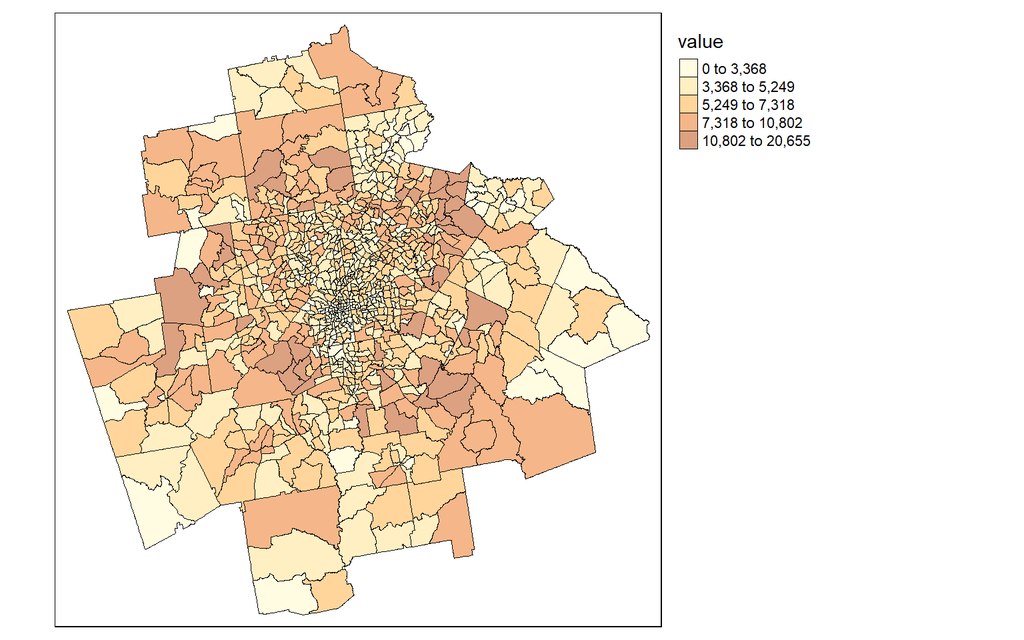

```r
tm_shape(gd_pop) +
  tm_fill(col = "value", alpha = 0.5, style = "jenks") +
  tm_borders(col = "black", lwd = 0.25) +
  tm_layout(legend.outside = TRUE)
```

# 2 Store Catchments

Ok, now that we are familiar with the three main datasets, we can actually get to some ‘spatial data science’. In this workshop we are going to be looking at the geodemographic profiles of two very different retailers:

**Whole Foods Market:**

The stores offer a wide variety of organic and natural foods, as well as a large selection of prepared foods… also has a number of unique features, such as a cheese shop, a wine bar and a coffee bar. Shopping at this luxury grocery store might cost shoppers more than they are willing to spend. According to a survey conducted by Business Insider, Whole Foods is 15% more expensive than general grocery stores such as Walmart and Kroger (source: [gobankingrates.com](https://www.gobankingrates.com/money/wealth/most-luxurious-grocery-stores-in-the-us/)).

**Ollie’s Bargain Outlet:**

Ollie’s Bargain Outlet is an American chain of discount closeout retailers… Its selection of merchandise comprises a variety of discounted household goods, apparel, pet supplies, kitchen pantry staples, and seasonal products (holiday, gardening, patio, pool and beach supplies); a majority of these items are unsold or overstocked merchandise that is purchased in bulk from other retailers and sold at discounted prices (source: [wiki](https://en.wikipedia.org/wiki/Ollie%27s_Bargain_Outlet)).

Let’s get the relevant places:

```r
wholefoods <- places %>%
  filter(brands == "Whole Foods Market")

ollies <- places %>%
  filter(brands == "Ollie's Bargain Outlet")
```

Let’s visualise these:

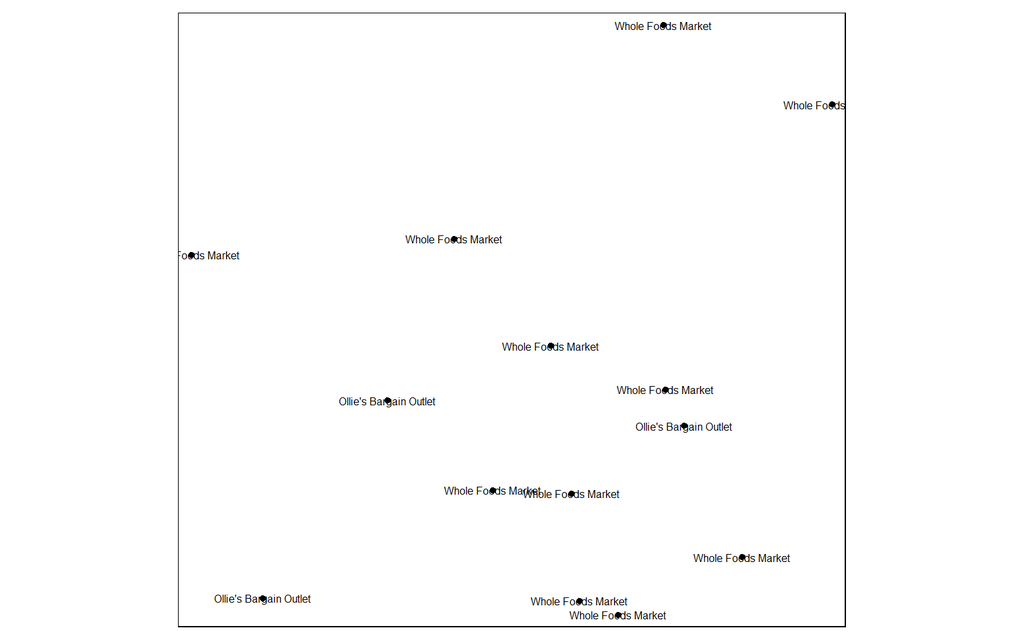

```r
q1 <- tm_shape(wholefoods) +
  tm_dots(col = "black", size = 0.1) +
  tm_text("brands", size = 0.5) +
  tm_shape(ollies) +
  tm_dots(col = "black", size = 0.1) +
  tm_text("brands", size = 0.5)

q1
```

And what does this look like with the geodemographic classification underneath:

```r
tm_shape(gd_pop) +
  tm_fill(col = "TractGroup", alpha = 0.5) +
  tm_borders(col = "black", lwd = 0.1) +
  tm_layout(legend.outside = TRUE) +
  q1
```

```
## Some legend labels were too wide. These labels have been resized to 0.63, 0.62. Increase legend.width (argument of tm_layout) to make the legend wider and therefore the labels larger.
```

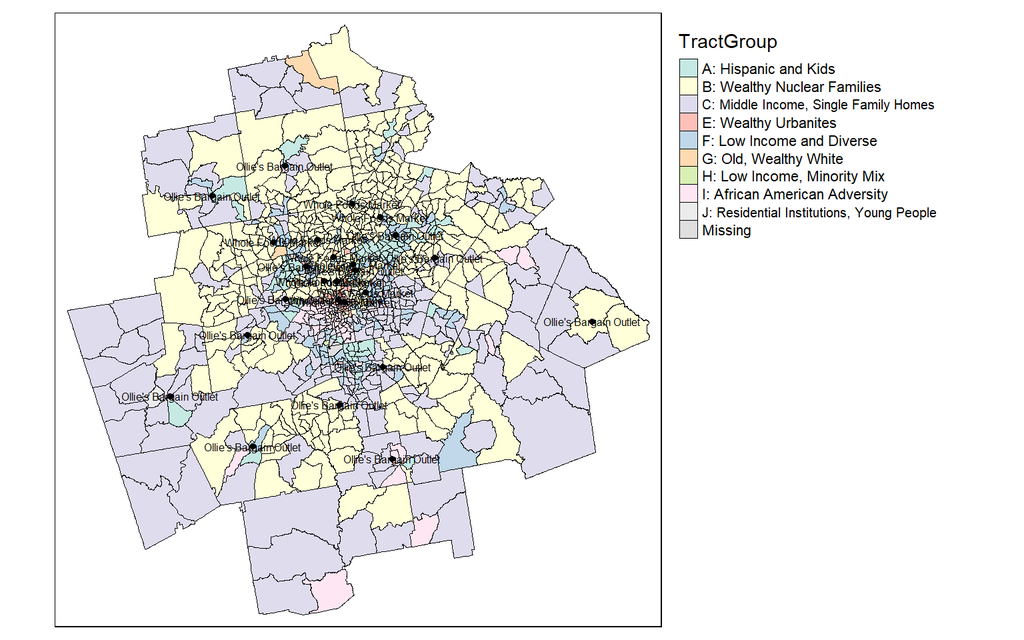

So there are some pretty obvious locational differences between them. But how can we assess this - **catchments**. Store catchments help us to better understand the characteristics of consumers that are likely to use these stores.

Let’s build a 1km buffer for whole foods stores:

```r
wholefoods_catch <- st_buffer(wholefoods, 1000)
```

What do these look like:

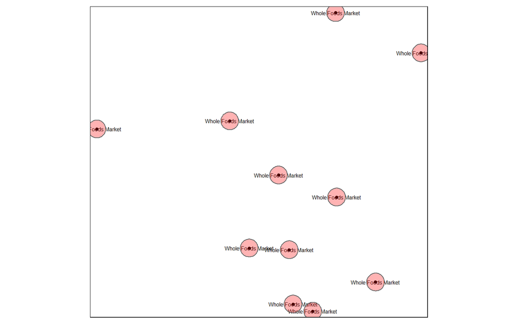

```r
q2 <- tm_shape(wholefoods) +
  tm_dots(col = "black", size = 0.1) +
  tm_text("brands", size = 0.5) +
  tm_shape(wholefoods_catch) +
  tm_polygons(col = "red", alpha = 0.3)
q2
```

And with the geodemographic:

```r
tm_shape(gd_pop) +
  tm_fill(col = "TractGroup", alpha = 0.5) +
  tm_borders(col = "black", lwd = 0.1) +
  tm_layout(legend.outside = TRUE) +
  q2
```

```
## Some legend labels were too wide. These labels have been resized to 0.63, 0.62. Increase legend.width (argument of tm_layout) to make the legend wider and therefore the labels larger.
```

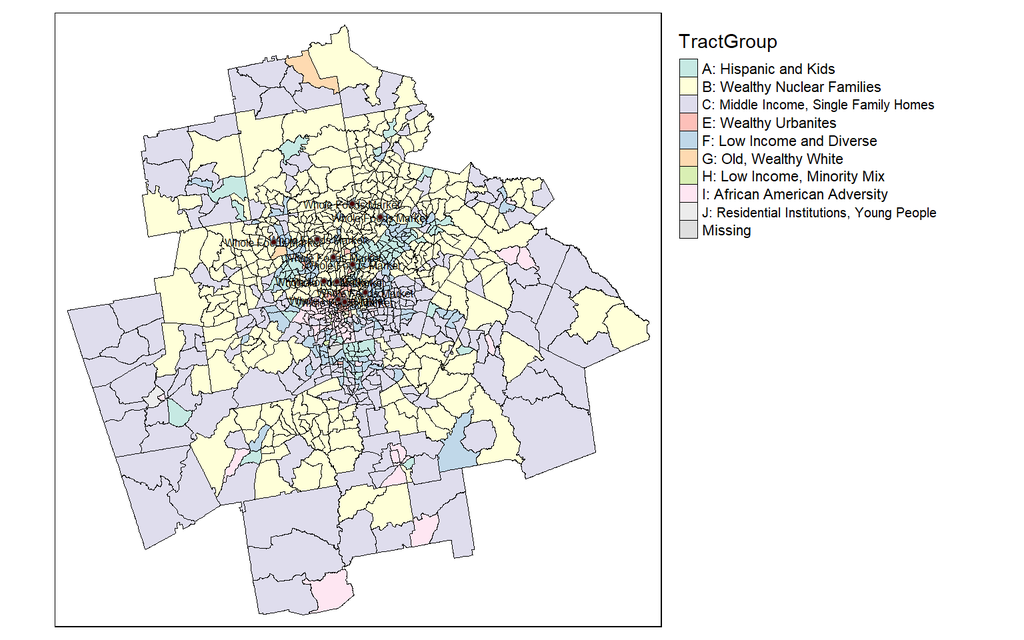

Let’s repeat the same for Ollie’s Bargain Outlet

```r
ollies_catch <- st_buffer(ollies, 1000)
```

What do these look like:

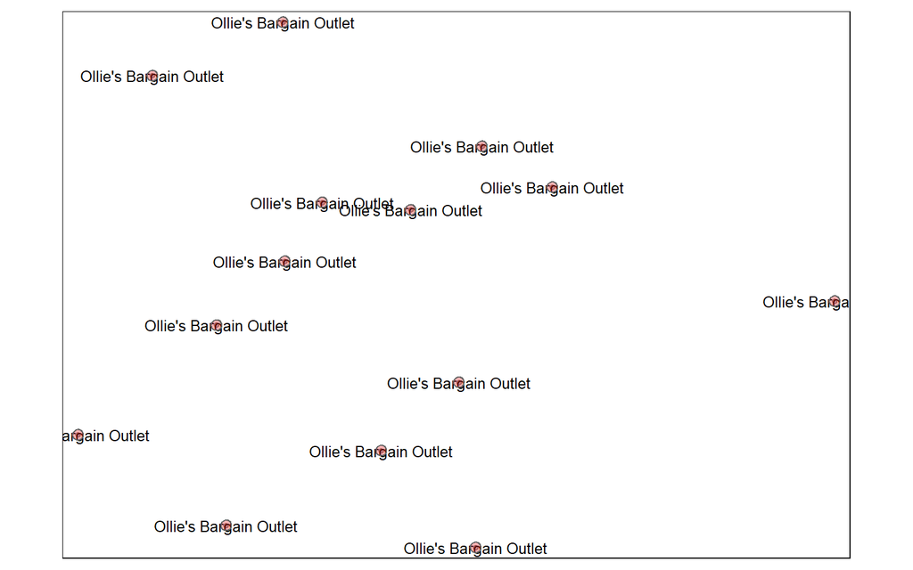

```r
q3 <- tm_shape(ollies) +
  tm_dots(col = "black", size = 0.1, alpha = 0.3) +
  tm_text("brands", size = 0.8) +
  tm_shape(ollies_catch) +
  tm_polygons(col = "red", alpha = 0.3)
q3
```

And with the geodemographic:

```r
tm_shape(gd_pop) +
  tm_fill(col = "TractGroup", alpha = 0.5) +
  tm_borders(col = "black", lwd = 0.1) +
  tm_layout(legend.outside = T) +
  q3
```

```
## Some legend labels were too wide. These labels have been resized to 0.63, 0.62. Increase legend.width (argument of tm_layout) to make the legend wider and therefore the labels larger.
```

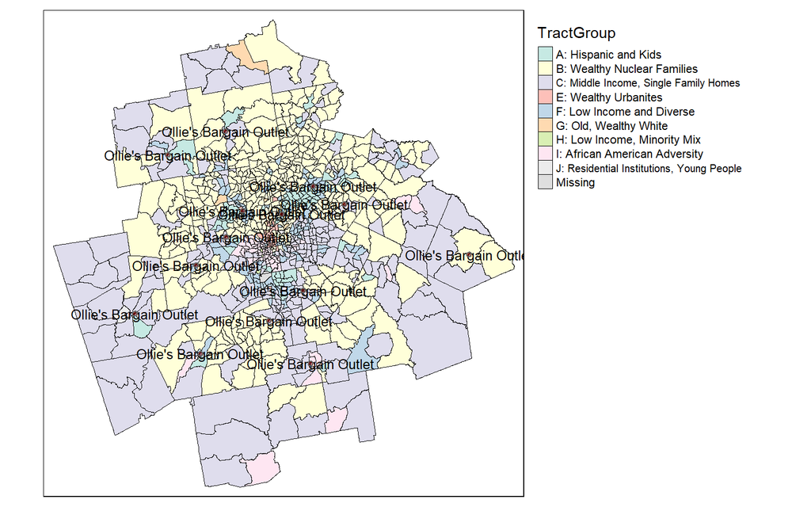

So there are some obvious differences between the general location and geodemographic profile of Whole Foods vs Ollie’s Bargain Outlet. So, how do we quantify this: **catchment profiling**.

# 3 Catchment Profiling

Catchment profiling is not a new approach, with retailers commonly using it to better understand the characteristics of people living in the catchments of their stores. However, what we want to introduce you to is a method through which to make this much simpler, accounting for a vast array of characteristics all at once: **catchment geodemographic profiling**.

## 3.1 Catchment Geodemographics (Whole Foods Market)

Ok, so we have already constructed catchment for each of these stores, enabling us to identify people living nearby that are more likely to shop there, we can profile exactly who these people are.

Let’s do a spatial join, allowing us to see what tracts (and geodemographics) fall within each store catchment:

```r
wholefoods_gd <- st_join(wholefoods_catch, gd_pop)
```

Let’s take a look at the output:

```r
head(wholefoods_gd)
```

```
## Simple feature collection with 6 features and 10 fields
## Geometry type: POLYGON
## Dimension:     XY
## Bounding box:  xmin: 1434471 ymin: -1105372 xmax: 1438666 ymax: -1089038
## Projected CRS: NAD27 / US National Atlas Equal Area
##          location_name            placekey             brands   top_category
## 1   Whole Foods Market zzw-223@8g7-4bz-jqf Whole Foods Market Grocery Stores
## 1.1 Whole Foods Market zzw-223@8g7-4bz-jqf Whole Foods Market Grocery Stores
## 1.2 Whole Foods Market zzw-223@8g7-4bz-jqf Whole Foods Market Grocery Stores
## 2   Whole Foods Market zzw-222@8g6-ynx-zfz Whole Foods Market Grocery Stores
## 2.1 Whole Foods Market zzw-222@8g6-ynx-zfz Whole Foods Market Grocery Stores
## 2.2 Whole Foods Market zzw-222@8g6-ynx-zfz Whole Foods Market Grocery Stores
##                                                   sub_category       GEOID
## 1   Supermarkets and Other Grocery (except Convenience) Stores 13121009700
## 1.1 Supermarkets and Other Grocery (except Convenience) Stores 13121009801
## 1.2 Supermarkets and Other Grocery (except Convenience) Stores 13121009802
## 2   Supermarkets and Other Grocery (except Convenience) Stores 13067030332
## 2.1 Supermarkets and Other Grocery (except Convenience) Stores 13067030333
## 2.2 Supermarkets and Other Grocery (except Convenience) Stores 13067030334
##                      TractGroup                                       NAME
## 1   B: Wealthy Nuclear Families    Census Tract 97, Fulton County, Georgia
## 1.1 B: Wealthy Nuclear Families Census Tract 98.01, Fulton County, Georgia
## 1.2 B: Wealthy Nuclear Families Census Tract 98.02, Fulton County, Georgia
## 2   B: Wealthy Nuclear Families  Census Tract 303.32, Cobb County, Georgia
## 2.1 B: Wealthy Nuclear Families  Census Tract 303.33, Cobb County, Georgia
## 2.2 B: Wealthy Nuclear Families  Census Tract 303.34, Cobb County, Georgia
##     variable value                           geom
## 1    P001001  3534 POLYGON ((1438666 -1104372,...
## 1.1  P001001  4680 POLYGON ((1438666 -1104372,...
## 1.2  P001001  4141 POLYGON ((1438666 -1104372,...
## 2    P001001  3148 POLYGON ((1436471 -1090038,...
## 2.1  P001001  6034 POLYGON ((1436471 -1090038,...
## 2.2  P001001  3246 POLYGON ((1436471 -1090038,...
```

What we want to do for each store is calculate the total catchment population in the catchment, and the total population disaggregated by geodemographic group. This is easy with tidyverse.

First, get the total population in each catchment:

```r
wholefood_profile <- wholefoods_gd %>%
  as.data.frame() %>%
  select(-c(geom)) %>%
  group_by(location_name, placekey) %>%
  summarise(catch_pop = sum(value))
```

Then get the total population by geodemographic group in each catchment:

```r
wholefood_gd_profile <- wholefoods_gd %>%
  as.data.frame() %>%
  select(-c(geom)) %>%
  group_by(location_name, placekey, TractGroup) %>%
  summarise(catch_gd_pop = sum(value))
```

Bring the two values together:

```r
wholefood_profile <- merge(wholefood_profile, wholefood_gd_profile, by = c("location_name", "placekey"), all.x = TRUE)
```

```r
head(wholefood_profile)
```

```
##        location_name            placekey catch_pop                  TractGroup
## 1 Whole Foods Market 222-224@8g6-y44-435     23815 B: Wealthy Nuclear Families
## 2 Whole Foods Market 222-224@8g6-y44-435     23815   F: Low Income and Diverse
## 3 Whole Foods Market zzw-222@8g6-ycc-3wk     32449 B: Wealthy Nuclear Families
## 4 Whole Foods Market zzw-222@8g6-ycc-3wk     32449   F: Low Income and Diverse
## 5 Whole Foods Market zzw-222@8g6-ykz-9vf     14710 B: Wealthy Nuclear Families
## 6 Whole Foods Market zzw-222@8g6-ykz-9vf     14710        E: Wealthy Urbanites
##   catch_gd_pop
## 1        19238
## 2         4577
## 3        22361
## 4        10088
## 5         4015
## 6         6826
```

Calculate proportion of catchment occupied by each geodemographic group:

```r
wholefood_profile_final <- wholefood_profile %>%
  mutate(gd_prop = (catch_gd_pop / catch_pop) * 100) %>%
  select(location_name, placekey, TractGroup, gd_prop)
```

Let’s visualise the breakdown of different groups between stores:

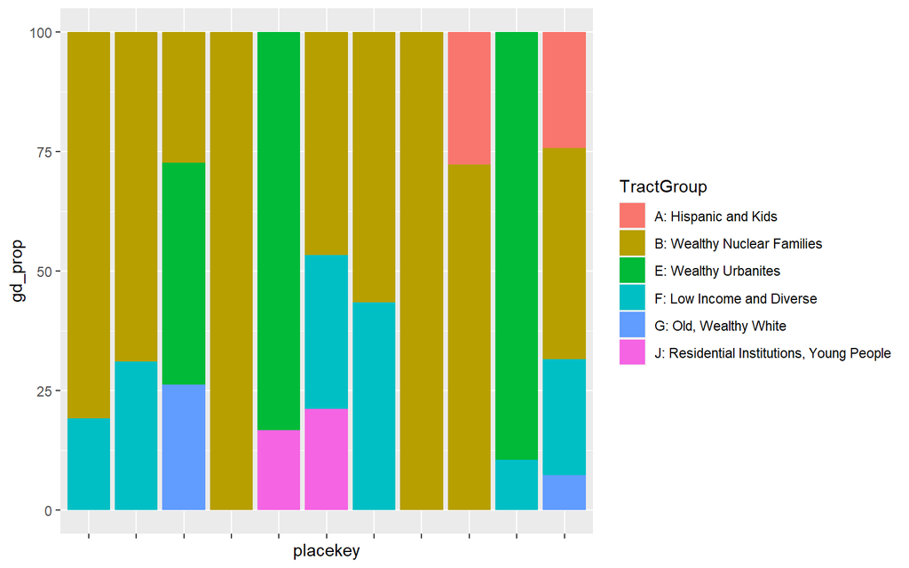

```r
wholefood_profile_final %>%
  complete(TractGroup, location_name, placekey, fill=list(gd_prop=0)) %>%
  ggplot(aes(fill = TractGroup, x = placekey, y = gd_prop)) +
  geom_bar(stat = "identity") +
  theme(axis.text.x = element_blank())
```

## 3.2 Catchment Geodemographics (Ollie’s Bargain Outlet)

Let’s repeat those steps for Ollie’s Bargain Outlet:

```r
ollies_gd <- st_join(ollies_catch, gd_pop)
ollies_profile <- ollies_gd %>%
  as.data.frame() %>%
  select(-c(geom)) %>%
  group_by(location_name, placekey) %>%
  summarise(catch_pop = sum(value))
ollies_gd_profile <- ollies_gd %>%
  as.data.frame() %>%
  select(-c(geom)) %>%
  group_by(location_name, placekey, TractGroup) %>%
  summarise(catch_gd_pop = sum(value))
ollies_profile <- merge(ollies_profile, ollies_gd_profile, by = c("location_name", "placekey"), all.x = TRUE)
ollies_profile_final <- ollies_profile %>%
  mutate(gd_prop = (catch_gd_pop / catch_pop) * 100) %>%
  select(location_name, placekey, TractGroup, gd_prop)
```

And visualise the output:

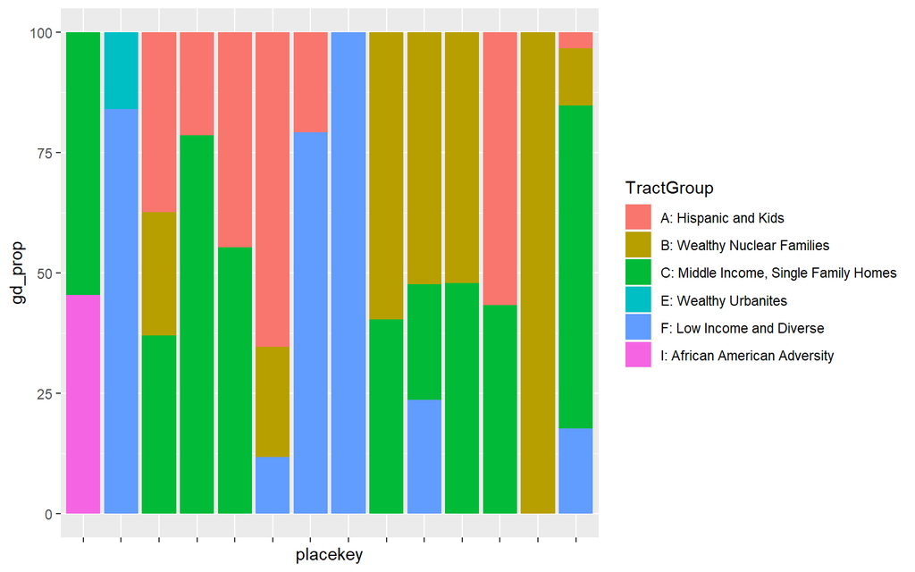

```r
ollies_profile_final %>%
  complete(TractGroup, location_name, placekey, fill=list(gd_prop=0)) %>%
  ggplot(aes(fill = TractGroup, x = placekey, y = gd_prop)) +
  geom_bar(stat = "identity") +
  theme(axis.text.x = element_blank())
```

## 3.3 Catchment spending power

Whilst it is useful to visualise differences in geodemographic profiles of store catchments, it is perhaps more useful to provide an empirical measure that quantifies these differences.

Let’s read in a file containing some information about the overall wealth of these different groups. For each geodemographic group, we have prepared a summary of the overall wealth taken straight from the pen portrait in [Spielman and Singleton (2015)](https://www.tandfonline.com/doi/full/10.1080/00045608.2015.1052335). Using these descriptions, we have assigned an arbitrary z-score (or weight) which can be used to weight these population proportions, and derive a composite index from them.

```r
zscores <- read.csv("Data/z-scores.csv")
```

```r
zscores
```

```
##                                  TractGroup
## 1                      A: Hispanic and Kids
## 2               B: Wealthy Nuclear Families
## 3     C: Middle Income, Single Family Homes
## 4                      E: Wealthy Urbanites
## 5                 F: Low Income and Diverse
## 6                     G: Old, Wealthy White
## 7               H: Low Income, Minority Mix
## 8             I: African American Adversity
## 9 J: Residential Institutions, Young People
##                                                  Wealth z.score
## 1                     Low incomes and public assistance    0.25
## 2           High incomes, few households less than $50k    1.00
## 3     Retirement income, low to middle household income    0.50
## 4          Wealthy, many households over $200k per year    1.00
## 5  Incomes below $40k common, few households over $100k    0.25
## 6             Retirement income, many households $150k+    0.50
## 7                     Low incomes and public assistance    0.25
## 8 Very poor, public assistance, incomes over $100k rare    0.05
## 9                                            Low income    0.25
```

Merge the z-scores onto the profiles:

```r
wholefood_profile_final <- merge(wholefood_profile_final, zscores[, c("TractGroup", "z.score")], all.x = TRUE)
```

Weight the geodemographic population proportions with the z scores:

```r
wholefood_profile_final <- wholefood_profile_final %>%
  arrange(location_name, placekey) %>%
  mutate(w_gd_prop = gd_prop * z.score)
```

Take a look:

```r
head(wholefood_profile_final)
```

```
##                    TractGroup      location_name            placekey  gd_prop
## 1 B: Wealthy Nuclear Families Whole Foods Market 222-224@8g6-y44-435 80.78102
## 2   F: Low Income and Diverse Whole Foods Market 222-224@8g6-y44-435 19.21898
## 3 B: Wealthy Nuclear Families Whole Foods Market zzw-222@8g6-ycc-3wk 68.91121
## 4   F: Low Income and Diverse Whole Foods Market zzw-222@8g6-ycc-3wk 31.08879
## 5 B: Wealthy Nuclear Families Whole Foods Market zzw-222@8g6-ykz-9vf 27.29436
## 6        E: Wealthy Urbanites Whole Foods Market zzw-222@8g6-ykz-9vf 46.40381
##   z.score w_gd_prop
## 1    1.00 80.781020
## 2    0.25  4.804745
## 3    1.00 68.911215
## 4    0.25  7.772196
## 5    1.00 27.294358
## 6    1.00 46.403807
```

```r
wholefood_out <- wholefood_profile_final %>%
  select(location_name, placekey, w_gd_prop) %>%
  group_by(location_name, placekey) %>%
  summarise(exp = sum(w_gd_prop))
wholefood_out
```

```
## # A tibble: 11 × 3
## # Groups:   location_name [1]
##    location_name      placekey              exp
##    <chr>              <chr>               <dbl>
##  1 Whole Foods Market 222-224@8g6-y44-435  85.6
##  2 Whole Foods Market zzw-222@8g6-ycc-3wk  76.7
##  3 Whole Foods Market zzw-222@8g6-ykz-9vf  86.8
##  4 Whole Foods Market zzw-222@8g6-ynx-zfz 100
##  5 Whole Foods Market zzw-222@8g7-46z-6p9  87.5
##  6 Whole Foods Market zzw-222@8gb-7gs-fxq  60.0
##  7 Whole Foods Market zzw-223@8g6-x8v-7qz  67.4
##  8 Whole Foods Market zzw-223@8g7-4bz-jqf 100
##  9 Whole Foods Market zzw-225@8g6-yjb-tjv  79.3
## 10 Whole Foods Market zzw-226@8g7-485-6c5  92.1
## 11 Whole Foods Market zzw-229@8g6-yjx-fmk  60.0
```

And repeat for Ollie’s:

```r
ollies_profile_final <- merge(ollies_profile_final, zscores[, c("TractGroup", "z.score")], all.x = TRUE)
ollies_profile_final <- ollies_profile_final %>%
  arrange(location_name, placekey) %>%
  mutate(w_gd_prop = gd_prop * z.score)
ollies_out <- ollies_profile_final %>%
  select(location_name, placekey, w_gd_prop) %>%
  group_by(location_name, placekey) %>%
  summarise(exp = sum(w_gd_prop))
ollies_out
```

```
## # A tibble: 14 × 3
## # Groups:   location_name [1]
##    location_name          placekey              exp
##    <chr>                  <chr>               <dbl>
##  1 Ollie's Bargain Outlet 222-222@8g7-32z-ht9  29.5
##  2 Ollie's Bargain Outlet 222-222@8g7-4cb-rhq  36.9
##  3 Ollie's Bargain Outlet 224-222@8g7-444-cwk  53.5
##  4 Ollie's Bargain Outlet 225-222@8gm-g7x-ch5  44.7
##  5 Ollie's Bargain Outlet 22f-222@8gb-6vd-tgk  38.8
##  6 Ollie's Bargain Outlet zzw-222@8g6-yjh-tjv  42.2
##  7 Ollie's Bargain Outlet zzw-222@8g6-yth-yn5  25
##  8 Ollie's Bargain Outlet zzw-222@8gm-drv-pn5  25
##  9 Ollie's Bargain Outlet zzw-223@8g7-33z-qmk  79.8
## 10 Ollie's Bargain Outlet zzw-223@8g7-4k9-8y9  70.2
## 11 Ollie's Bargain Outlet zzw-225@8g6-xgv-kvf  76.0
## 12 Ollie's Bargain Outlet zzw-226@8gb-3d6-w8v  35.8
## 13 Ollie's Bargain Outlet zzy-222@8g6-zsp-4n5 100
## 14 Ollie's Bargain Outlet zzy-223@8g6-xrb-xbk  50.7
```

Ok, let’s compare the distribution of our score across the two types of stores:

```r
stat <- rbind(ollies_out, wholefood_out)
stat %>%
  group_by(location_name) %>%
  summarise(medianExp = median(exp))
```

```
## # A tibble: 2 × 2
##   location_name          medianExp
##   <chr>                      <dbl>
## 1 Ollie's Bargain Outlet      43.4
## 2 Whole Foods Market          85.6
```

## 3.4 Implications

So what does all of this mean? What can such insights be used for?